# sBread - South America case study

Author

Peter Ranacher

This markdown prepares language polygons for analysis with the `sBread` software (https://github.com/takuya-tkhs/sBread). `sBread` is a Bayesian algorithm modelling the spread of a phenomenon in geographic space (Takahashi et al. 2023). Here, we use the algorithm to infer the spatial diffusion of the Indo-European (IE) languages in South America. We create a hexagonal grid for South America, match language areas to the grid and evaluate neighbourhood relationships between grid cells.

The script returns two items:

1. `history`: a matrix with snapshots of the spatial distribution of IE languages from the first arrivals in the 16th century until today mapped to a spatial grid. The initial and current distribution of IE are known, while the distributions between them will be inferred. In the matrix, the rows are snapshots in time, and the columns are the spatial grid cells.
2. `adj_list`: an adjacency list of the neighbourhood relationships in the spatial grid.

## Packages

```r
library(tidyverse)
library(sf)
library(spdep)
library(igraph)
library(gridExtra)
library(kableExtra)
```

## A hexagonal grid for South America

First, we load the land polygons, including major islands from [Natural Earth 1:10m Physical Vectors](https://www.naturalearthdata.com/downloads/10m-physical-vectors). We crop out the South American continent and parts of the Isthmus of Panama, removing North America and all islands. Subsequently, we reproject South America to the Transverse Cylindrical Equal Area coordinate reference system (CRS). This metric and equal-area CRS was suggested by the Projection Wizard tool (Šavrič, Jenny, and Jenny 2016).

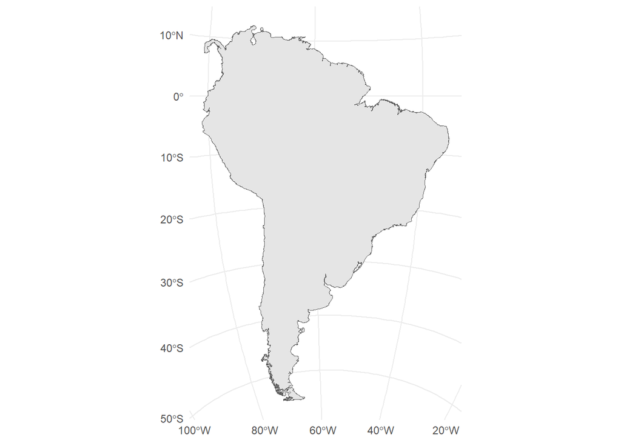

```r
# Load polygon, crop and reproject to an equal area CRS

crs_eq_area <- st_crs("+proj=tcea +lon_0=-57.3046875 +datum=WGS84 +units=m +no_defs")

america <- st_read("data/ne_10m_land/ne_10m_land.shp") %>%
  st_crop(xmin = -100 , ymin = -60, xmax = -20, ymax = 15) %>%
  st_cast("POLYGON") %>%
  filter(!is.null(geometry)) %>%
  mutate(area = st_area(geometry) %>% as.vector()) %>%
  arrange(desc(area)) %>%
  slice(1:2) %>%
  st_difference(st_bbox(c(xmin = -100, ymin = 6,
                          xmax = -81, ymax = 20),
                        crs = 4326) %>% st_as_sfc()) %>%
  st_transform(crs_eq_area)

ggplot(america) +
  geom_sf() +
  theme_minimal()
```

Next, we generate a hexagonal grid. We obtain the bounding box of South America and fill it with hexagonal polygons with a cell size of 50 km. We apply a filter to retain only those grid cells intersecting with South America.

```r
# cell size in metres
cellsize = 50000

# Generate the hexagonal grid
bbox <- america %>% st_bbox() %>% st_as_sfc()
grid <- st_make_grid(bbox, what = "polygons",
                     cellsize = cellsize, square = FALSE, flat_topped = FALSE) %>%
  st_as_sf()

st_geometry(grid) = "geom"

# Filter grid cells intersecting with South America
america_grid <- grid %>%
  st_filter(america, .predicates = st_intersects) %>%
  mutate(id = row_number())
```

## Matching language areas to the grid

We match the IE languages to the hexagonal grid. The current language areas were digitised from the Atlas of the World’s Languages (Asher and Moseley 2018). The historical locations of the first settlements of Indo-European speakers were compiled by Geneviève Hannes in the Master’s thesis titled ’Interpolating spatial language evolution in South America(Hannes 2023)

```r
current_ie <- st_read("data/language_polygons_current.json") %>%
  filter(family == "Indo-European") %>%
  st_transform(crs_eq_area)


historical_ie <- read_csv("data/historical_seeds_ie.csv") %>%
  st_as_sf(coords = c("lon", "lat"), crs = st_crs(4326)) %>%
   st_transform(crs_eq_area)

# Arrival of first languages
t_initial <- historical_ie %>%
  filter(year == min(year)) %>%
  pull(year)

# Current snapshot
t_final <- 1990

# Time interval between snapshots
delta_t <- 2
```

The first IE languages arrived in South America in 1510, with subsequent arrivals soon after. Table 1 shows the most important early IE settlements in South America and the year they were founded.

| Settlement | Year |
| --- | --- |
| Santa Maria la Antigua del Darien | 1510 |
| Panama City | 1519 |
| Cumaná | 1521 |
| Santa Marta | 1525 |
| Piura | 1532 |
| Sao Vicente | 1532 |
| Cartagena | 1533 |
| Cuzco | 1533 |
| Quito | 1534 |
| Trujillo | 1534 |
| Lima | 1535 |
| Asunción | 1537 |
| Olinda | 1537 |
| Bogotá | 1538 |
| Sucre | 1538 |
| Santiago de Chile | 1544 |
| Potosí | 1545 |
| La Paz | 1548 |
| Salvador da Bahia | 1549 |
| Concepción | 1550 |
| Huancavelica | 1563 |
| Rio de Janeiro | 1567 |
| Caracas | 1567 |
| Cochabamba | 1574 |
| Buenos Aires | 1580 |

Table 1: First IE arrivals in South America

The current geographic distribution was mapped for 1990 , yielding 480 years during which IE diffused in South America. `sBread` models the spatial diffusion as consecutive snapshots linked with a Markov process. Each snapshot shows the geographic distribution of languages at a specific point in time, with `1` indicating the presence of IE, `0`the absence and `-1` unknown. The initial and final snapshots are known, all others unknown, except for locations with subsequent IE arrivals.

For ease of analysis, the time interval between two snapshots should be a multiple of a year. Here, we use two years, yielding 241 snapshots. We collect the history in a matrix, where a row is a snapshot at time `t`, and a column is the spatial location in the grid.

```r
t_snapshots <- seq(t_initial, t_final, by = delta_t)

# For each new arrival find the closest year in t_snapshots
historical_ie <- historical_ie %>%
  rowwise() %>%
  mutate(match_year = min(t_snapshots[t_snapshots >= year]))

history <- sapply(t_snapshots, function (t) {
  if (t == t_initial) {
    ifelse(st_intersects(america_grid, historical_ie %>%
                           filter(match_year == t), sparse = F) %>%
             rowSums() > 0L, 1, 0)
  } else if (t == t_final) {
    ifelse(st_intersects(america_grid, current_ie, sparse = F) %>%
             rowSums() > 0L, 1, 0)
  } else {
    ifelse(st_intersects(america_grid, historical_ie %>%
                           filter(match_year == t), sparse = F) %>%
             rowSums() > 0L, 1, -1)}}, simplify = T) %>% t
```

The plot below shows the initial and current distribution of the IE languages in South America.

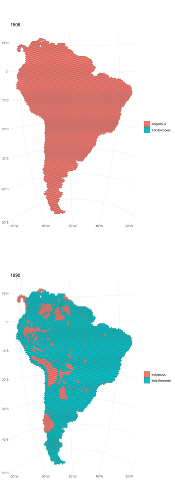

```r
# Join the first and last row of the matrix with the grid
america_grid <- america_grid %>% left_join(
  data.frame(initial = history[1, ],
             current = history[nrow(history), ]) %>%
  mutate(id = row_number()), by = "id")

america_initial_map <- ggplot(america_grid) +
  geom_sf(mapping = aes(fill = factor(initial))) +
  ggtitle("1509") +
  labs(fill = NULL) +
  scale_fill_discrete(labels = c("indigenous", "Indo-European")) +
  theme_minimal()

america_current_map <- ggplot(america_grid) +
  geom_sf(mapping = aes(fill = factor(current))) +
  ggtitle("1990") +
  labs(fill = NULL) +
  scale_fill_discrete(labels = c("indigenous", "Indo-European")) +
  theme_minimal()

grid.arrange(america_initial_map, america_current_map, ncol = 1, nrow = 2)
```

## Grid neighbours

We evaluate the neighbourhood relationships in the hexagonal grid. Two cells are considered neighbours if they share a common border. We convert neighbourhoods into a graph and extract the adjacency list.

```r
adj_list <- poly2nb(america_grid) %>%
  nb2mat(style = "B") %>%
  graph_from_adjacency_matrix(mode = "undirected") %>%
  as_adj_list()
```

## References

Asher, Ronald E, and Christopher Moseley. 2018. *Atlas of the World’s Languages*. Routledge.

Hannes, Geneviève. 2023. “Interpolating Spatial Language Evolution in South America.” Master’s thesis, University of Zurich, Department of Geography.

Šavrič, Bojan, Bernhard Jenny, and Helen Jenny. 2016. “Projection Wizard – an Online Map Projection Selection Tool.” *Cartographic Journal The* 53 (May): 177–85. https://doi.org/10.1080/00087041.2015.1131938.

Takahashi, Takuya, Geneviève Hannes, Nico Neureiter, and Peter Ranacher. 2023. “Inferring the History of Spatial Diffusion Processes.” In *12th International Conference on Geographic Information Science (GIScience 2023)*, edited by Roger Beecham, Jed A. Long, Dianna Smith, Qunshan Zhao, and Sarah Wise, 277:71:1–6. Leibniz International Proceedings in Informatics (LIPIcs). Dagstuhl, Germany: Schloss Dagstuhl – Leibniz-Zentrum für Informatik. https://doi.org/10.4230/LIPIcs.GIScience.2023.71.